# Proyecto 1

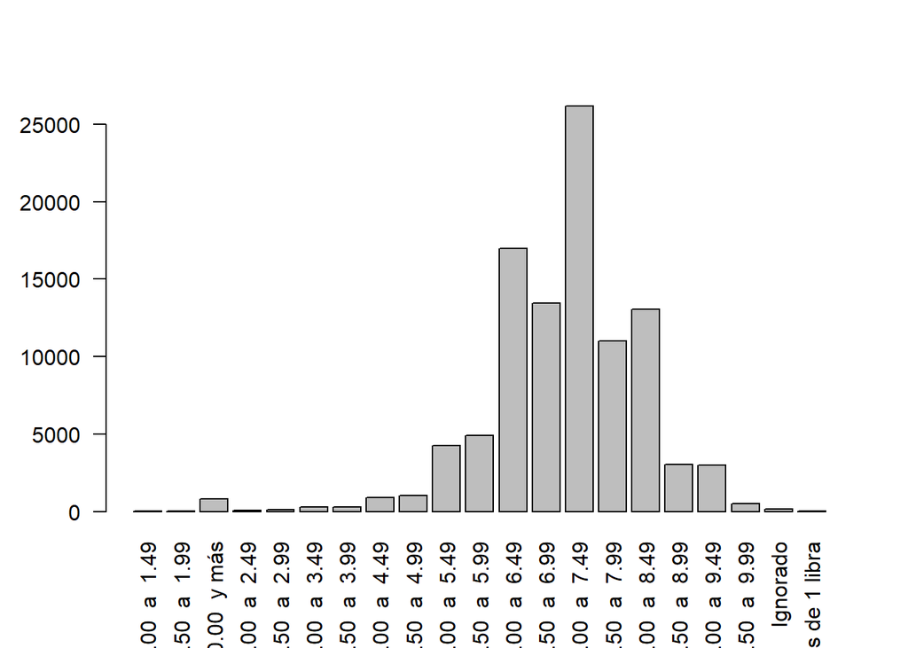

```
## [1] "Zacapa"
```

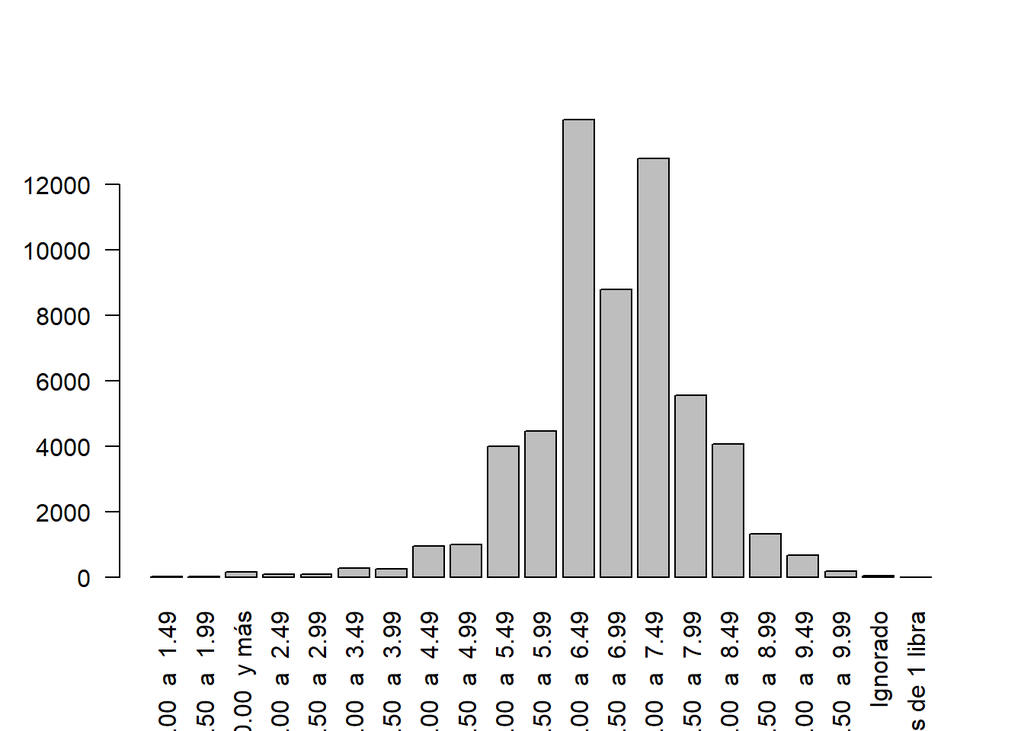

```
## [1] "Chiquimula"
```

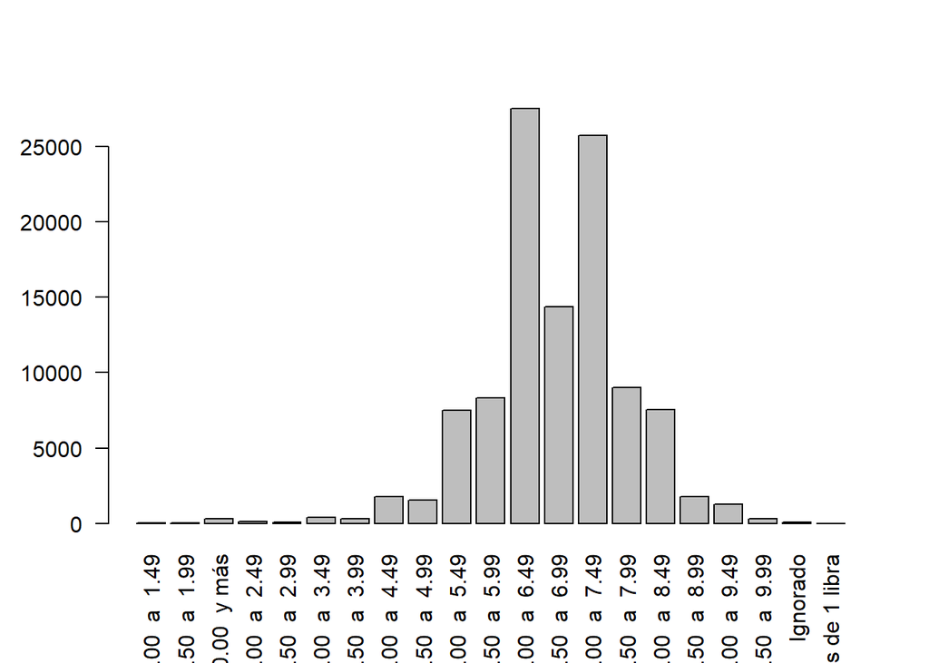

```
## [1] "Jalapa"
```

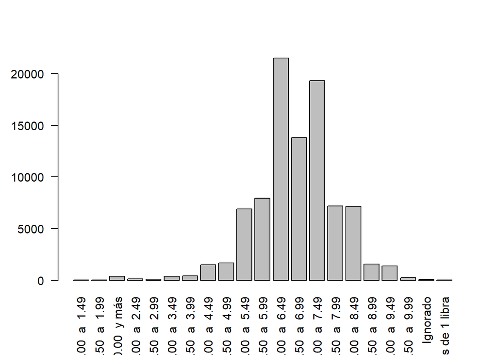

```
## [1] "Jutiapa"
```

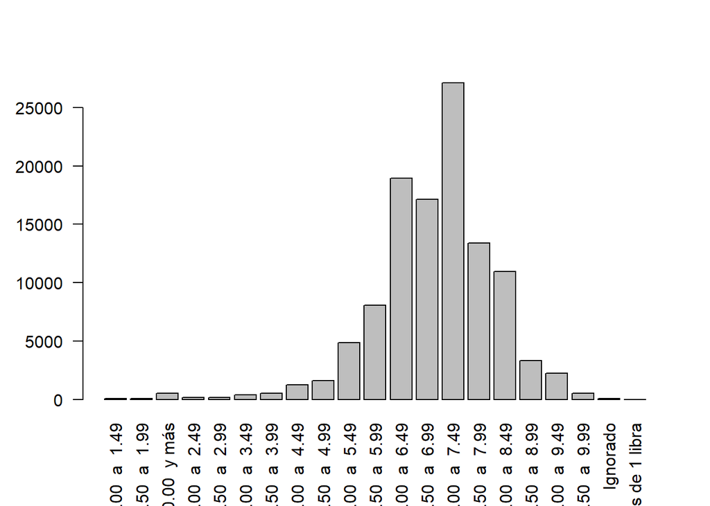

```
## [1] "Extranjero"
```

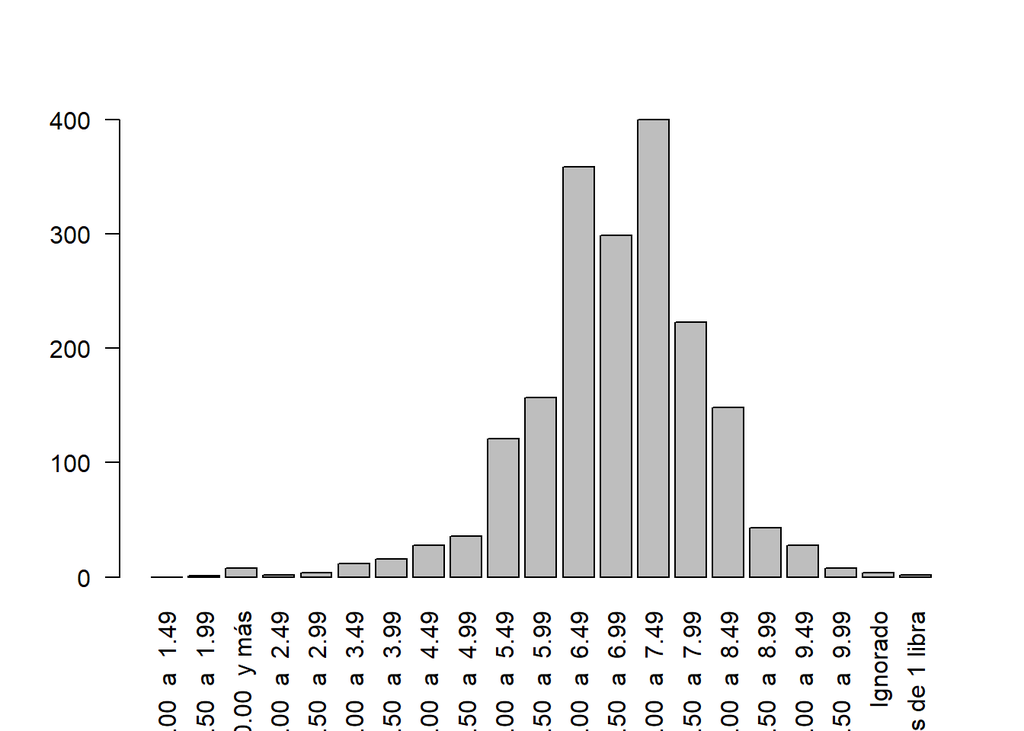

```
## [1] "Ignorado"
```

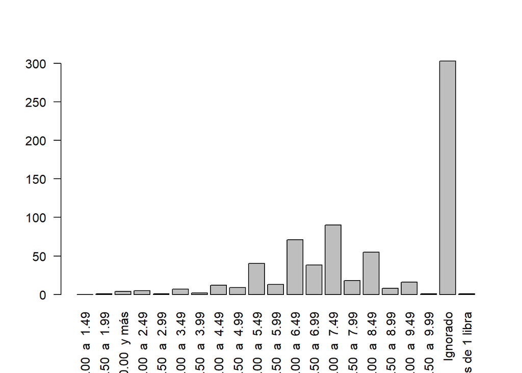

Luego de esto se quizo ver como era la distribucion de nacimientos por edades, se obtuvieron los siguientes resultados:

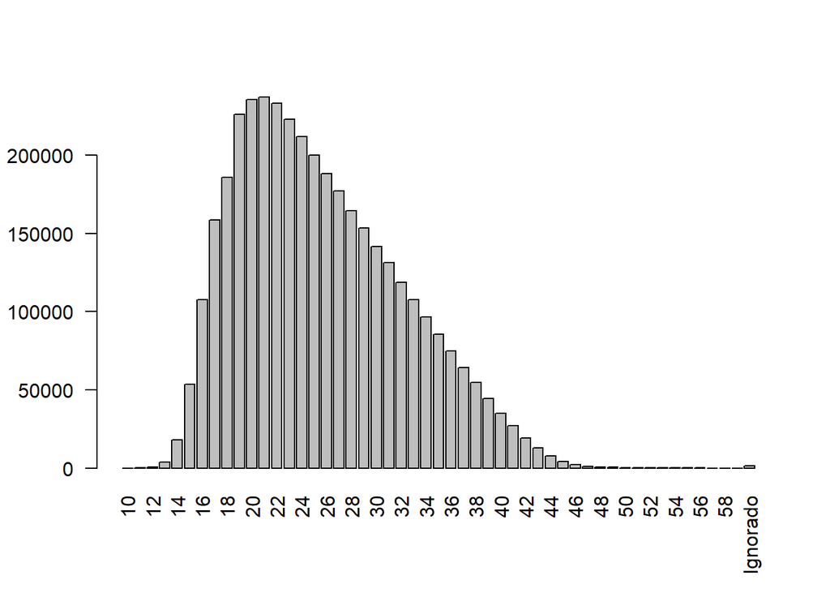

A continuación se verá por departamento:

```r
nac_edad0 <- nac_por_dpto_edades_simples %>% filter(Edad %in% (10:15))

summary(nac_edad0)
```

```
##      Edad               Total          Guatemala      El.Progreso
##  Length:59          Min.   :   1.0   Min.   :  0.0   Min.   : 0.00
##  Class :character   1st Qu.:  13.5   1st Qu.:  1.0   1st Qu.: 0.00
##  Mode  :character   Median : 262.0   Median : 20.0   Median : 2.00
##                     Mean   :1289.5   Mean   :130.1   Mean   :13.58
##                     3rd Qu.:1642.0   3rd Qu.:180.5   3rd Qu.:16.00
##                     Max.   :6821.0   Max.   :641.0   Max.   :72.00
##   Sacatepéquez   Chimaltenango      Escuintla        Santa.Rosa
##  Min.   : 0.00   Min.   :  0.00   Min.   :  0.00   Min.   :  0.00
##  1st Qu.: 0.00   1st Qu.:  0.00   1st Qu.:  1.50   1st Qu.:  0.00
##  Median : 2.00   Median :  2.00   Median : 17.00   Median :  5.00
##  Mean   :14.69   Mean   : 25.73   Mean   : 71.51   Mean   : 35.53
##  3rd Qu.:18.00   3rd Qu.: 31.00   3rd Qu.:100.00   3rd Qu.: 43.00
##  Max.   :76.00   Max.   :155.00   Max.   :390.00   Max.   :215.00
##      Sololá        Totonicapán     Quetzaltenango   Suchitepéquez
##  Min.   :  0.00   Min.   :  0.00   Min.   :  0.00   Min.   :  0.00
##  1st Qu.:  0.00   1st Qu.:  0.00   1st Qu.:  0.50   1st Qu.:  1.00
##  Median :  2.00   Median :  3.00   Median : 12.00   Median :  9.00
##  Mean   : 21.68   Mean   : 25.24   Mean   : 71.78   Mean   : 45.46
##  3rd Qu.: 26.50   3rd Qu.: 29.50   3rd Qu.: 88.50   3rd Qu.: 60.00
##  Max.   :153.00   Max.   :169.00   Max.   :397.00   Max.   :239.00
##    Retalhuleu       San.Marcos    Huehuetenango       Quiché
##  Min.   :  0.00   Min.   :  0.0   Min.   :  0.0   Min.   :  0.00
##  1st Qu.:  0.00   1st Qu.:  1.0   1st Qu.:  1.5   1st Qu.:  1.00
##  Median :  3.00   Median : 21.0   Median : 17.0   Median : 17.00
##  Mean   : 30.51   Mean   :103.9   Mean   :146.3   Mean   : 95.14
##  3rd Qu.: 45.50   3rd Qu.:140.0   3rd Qu.:206.0   3rd Qu.:128.50
##  Max.   :161.00   Max.   :531.0   Max.   :755.0   Max.   :532.00
##   Baja.Verapaz     Alta.Verapaz       Petén           Izabal
##  Min.   :  0.00   Min.   :  0.0   Min.   :  0.0   Min.   :  0.00
##  1st Qu.:  0.00   1st Qu.:  2.0   1st Qu.:  2.0   1st Qu.:  1.00
##  Median :  4.00   Median : 26.0   Median : 26.0   Median : 10.00
##  Mean   : 27.39   Mean   :133.7   Mean   :100.6   Mean   : 52.22
##  3rd Qu.: 36.00   3rd Qu.:175.0   3rd Qu.:155.0   3rd Qu.: 75.00
##  Max.   :152.00   Max.   :680.0   Max.   :509.0   Max.   :255.00
##      Zacapa         Chiquimula         Jalapa          Jutiapa
##  Min.   :  0.00   Min.   :  0.00   Min.   :  0.00   Min.   :  0.0
##  1st Qu.:  0.50   1st Qu.:  0.50   1st Qu.:  1.00   1st Qu.:  0.5
##  Median :  5.00   Median :  5.00   Median :  9.00   Median :  7.0
##  Mean   : 24.76   Mean   : 41.32   Mean   : 36.03   Mean   : 41.2
##  3rd Qu.: 36.00   3rd Qu.: 53.50   3rd Qu.: 51.50   3rd Qu.: 49.5
##  Max.   :130.00   Max.   :221.00   Max.   :179.00   Max.   :235.0
##    Extranjero       Ignorado            anio
##  Min.   :0.000   Min.   : 0.0000   Min.   :2010
##  1st Qu.:0.000   1st Qu.: 0.0000   1st Qu.:2012
##  Median :0.000   Median : 0.0000   Median :2014
##  Mean   :0.322   Mean   : 0.8305   Mean   :2014
##  3rd Qu.:0.000   3rd Qu.: 1.0000   3rd Qu.:2017
##  Max.   :3.000   Max.   :10.0000   Max.   :2019
```

### - Correlaciones Entre las Variables

Para hacer el estudio de correlación para cada tabla, solo se puede aplicar a variables cuantitativas, se investigó si se puede convertir las variables cuantitativas a numeros diferentes aleatorios, pero las únicas formas que encontramos eran muy complejas en cuestion de tiempo. Por esta razón, se hizo el estudio de correlaión solo entre variables cuantitativas actuales.

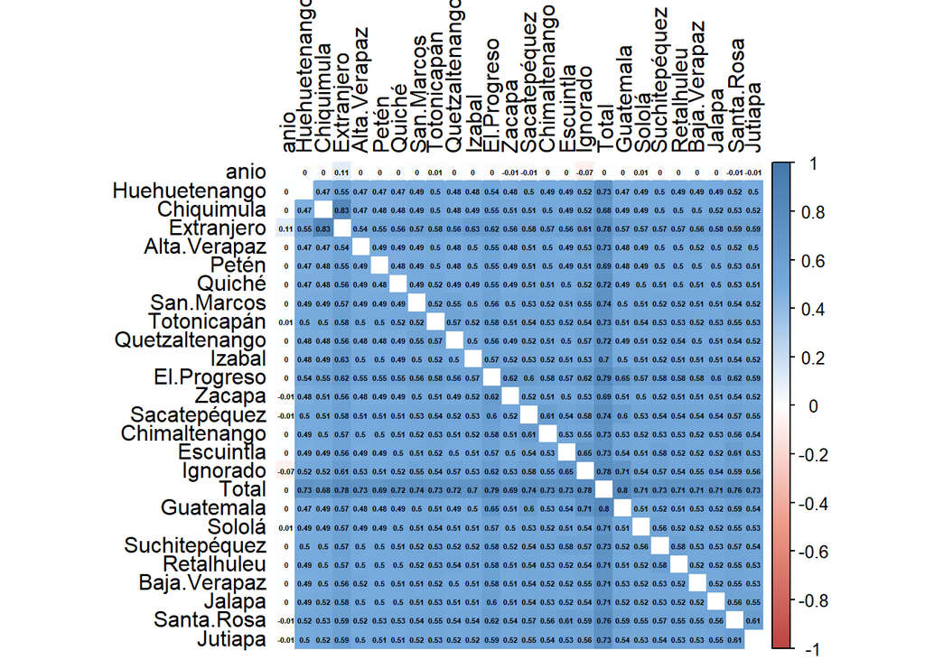

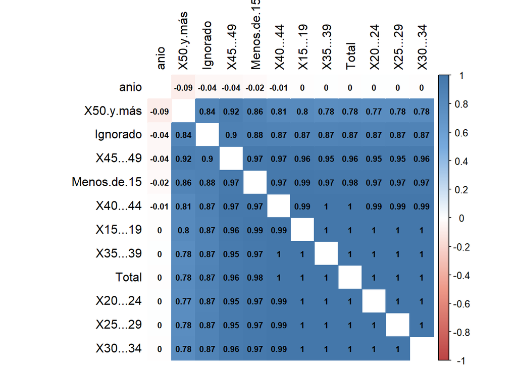

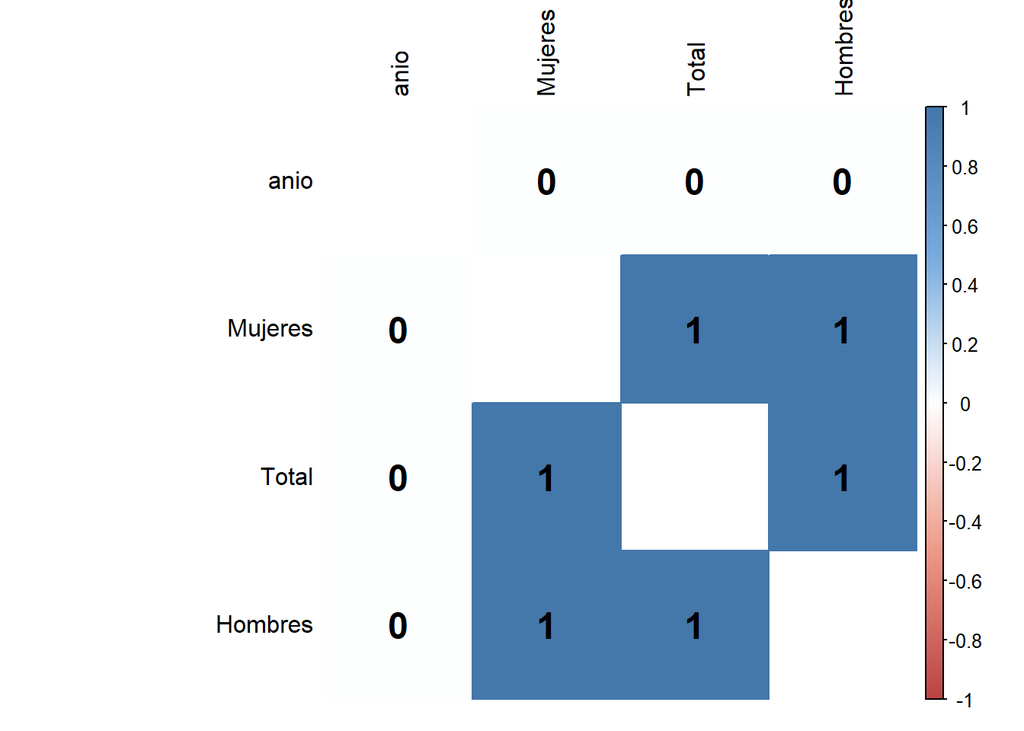

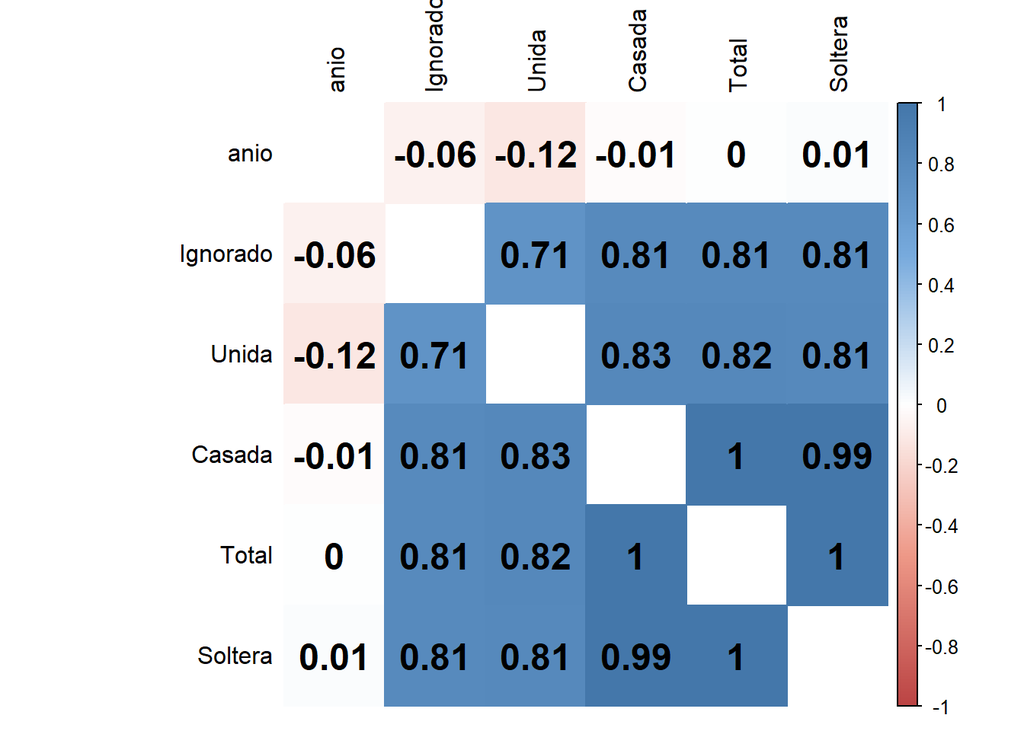

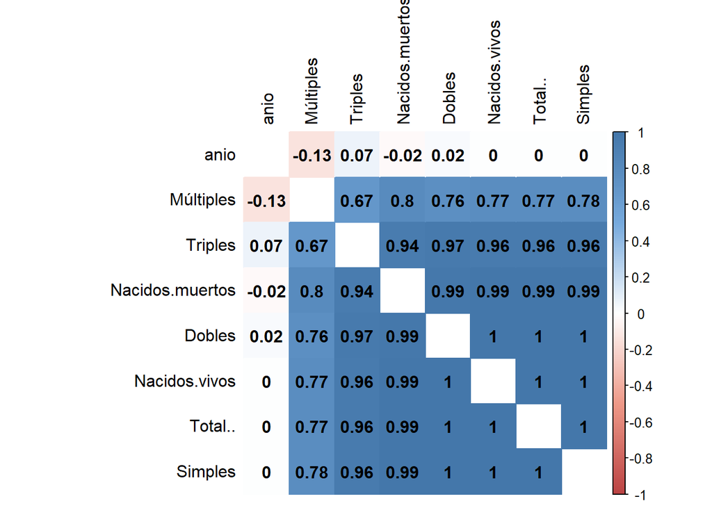

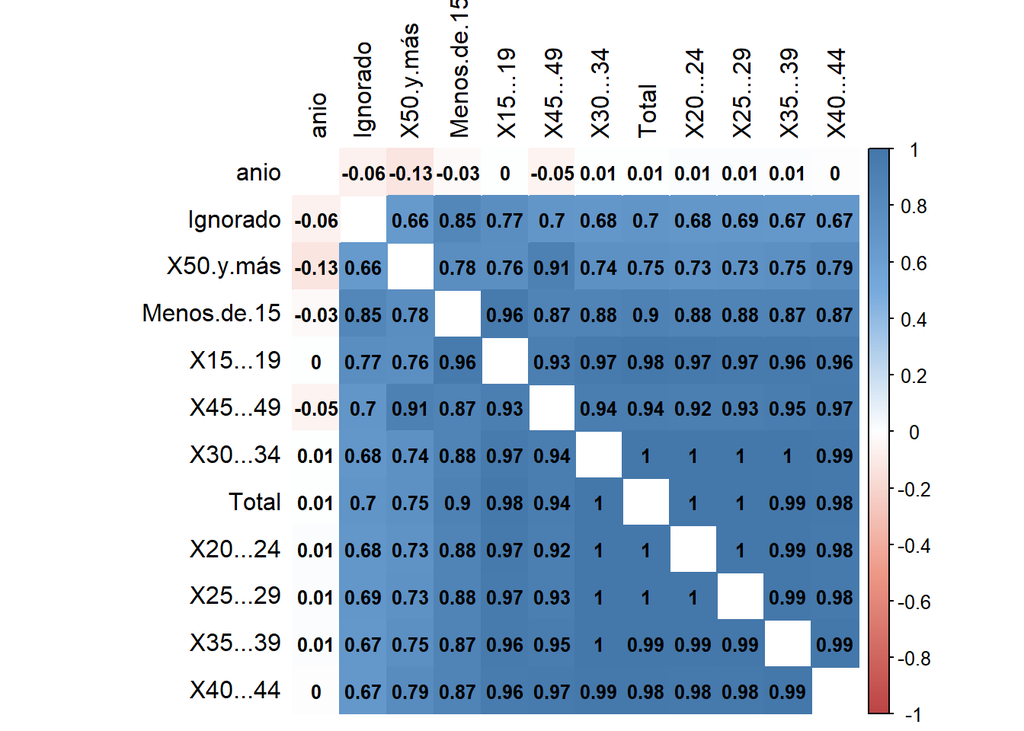

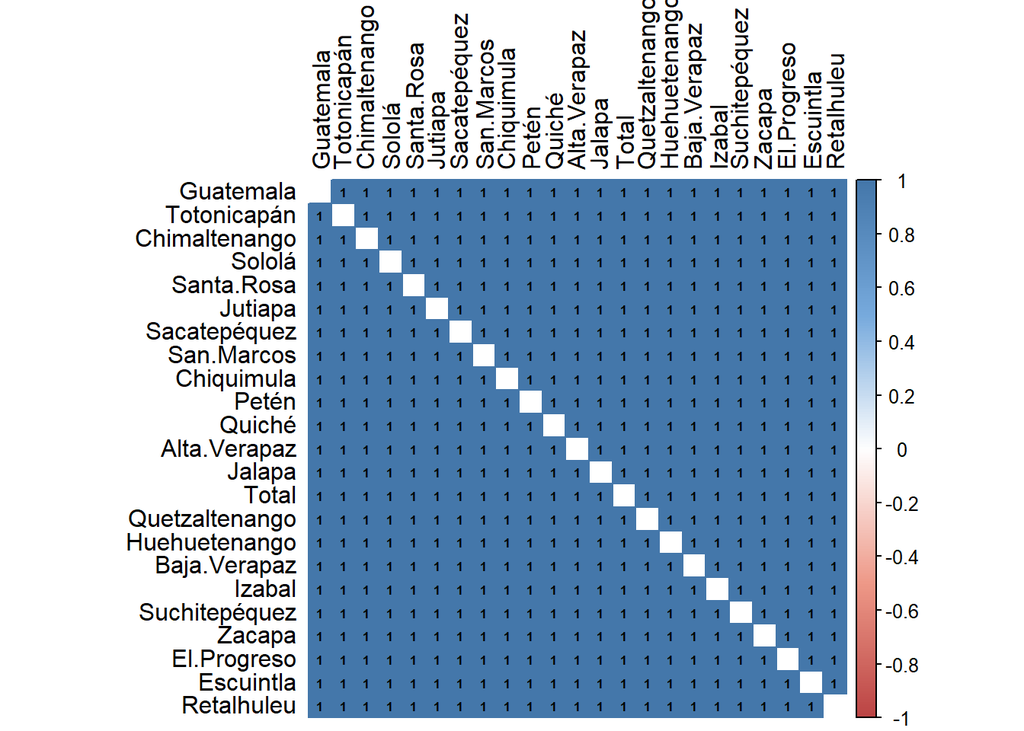

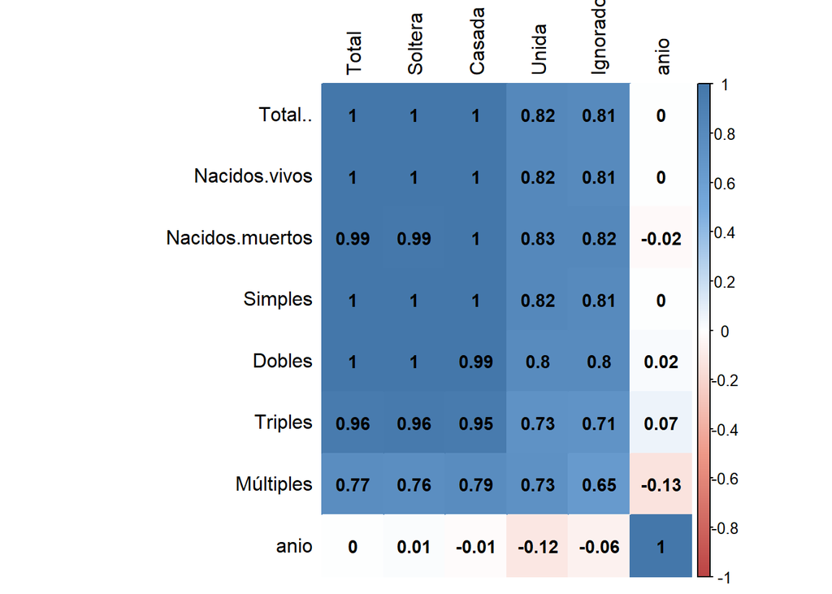

### - Número de Clusters

Para analizar de mejor manera la informacion se hara un agrupamiento. Por lo que se hara una grafica de codo para determinar la cantidad de grupos adecuados para el analisis de datos.

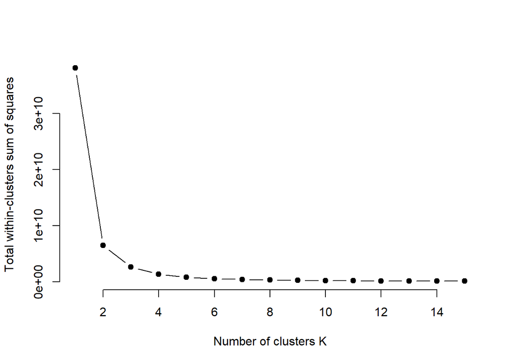

Para realizar la grafica de codo se seleccionaron las variables cuantitativas que consideramos mas relevantes que en este caso fueron la cantidad de nacimientos por departamento.

El grafico antes mostrado nos indica que podemos hacer una eleccion de 3 o 5 clusters por lo que se decidira utilizar 3 clusters para el analisis de datos.

### - Agrupamiento

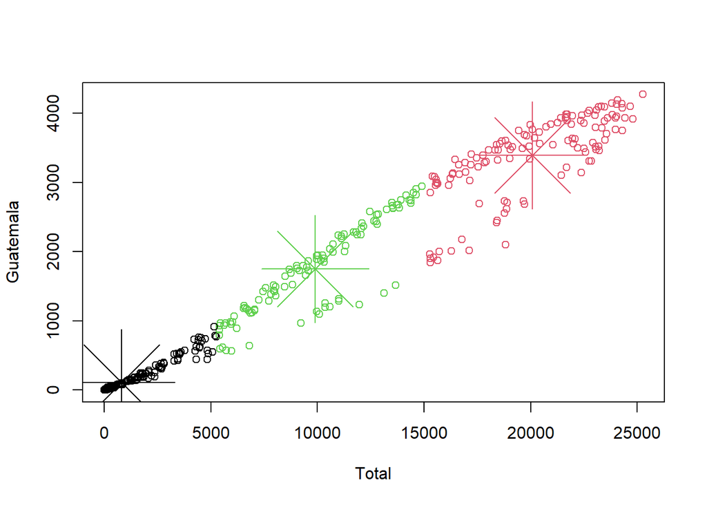

Luego del agrupamiento se obtuvo la grafica anterior similar a la anterior, sin embargo, dada la cantidad de datos y la cercania entre valores no se puede apreciar con certeza los clusters generados. Por lo que que decidimos separar los clusters por variables especificas. Por ejemplo, por departamento y su total de nacimientos.

De esta manera se pudo apreciar mejor la division entre grupoos. Y se realizo asi con todas las variables que considermaos necesarias para el analisis.

### - Calidad del Agrupamiento

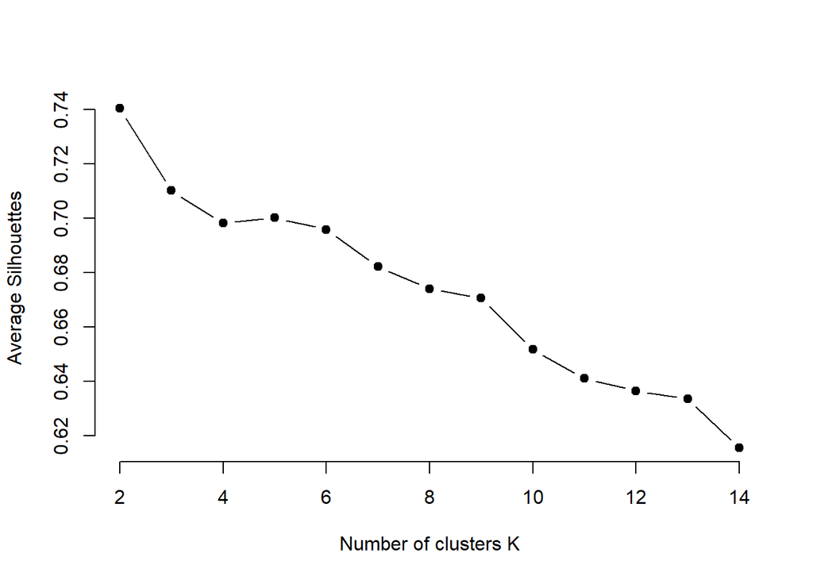

### - Hallazgos en el análisis exploratorio

Para realizar el análisis exploratorio se inició con la clasificación de las variables por cada uno de los sets de datos, iniciando por la variables que nos ayudaban a determinar el departamento de ocurrencia del nacimiento, entre estas variables están el mes, departamento y anio.

Después se procedió a hacer análisis por agrupamientos donde se clasificaron los datos por edad de la madre, estado civil de la misma, nacimientos por escolaridad según el numero de hijos tenidos, entre otros.

Pasando a la sección de la estadística descriptiva primero se procedió a hacer un analisis muy a grandes rasgos sobre las situación de nacimientos por cada departamento, durante los 10 anios. Dentro de esta seccion y también clasificado por departamento se indago sobre nacimientos por grupos de edad de la madre, según departamento y pueblo de pertenencia de la madre, nacimientos por grupos de edad de la madre, según departamento y municipio de su residencia, entre otros.

Pasando a los resultados y los hallazgos más relevante encontrados. Vemos que en la seccion de gráficos exploratorios existe una gran cantidad de diferencias entre la cantidad de nacidos por cada uno de los departamentos entre los departamentos con mayor cantidad de nacimientos se encuentran Guatemala, San Marcos y Huehuetenango.

También pudimos determinar que entre todos los 10 anios de los cuales se tenia registro el 2015 es donde se ve uno de los mayores incrementos en la taza de nacimiento, y después de esto podemos ver que en los últimos años hemos observado una tendencia al decremento en la taza de nacimiento, aunque esta no es altamente significativa también puede ser indicativo de otros factores.

También se analizo las tendencias en los nacimientos a lo largo de los 10 anios, en este caso se decidió separar los departamentos en grupos de 7 y el ultimo de 8 departamentos, esta separación se hizo únicamente con objetivo de poder visualizarlo en un poco mas de orden, ya que 22 lineas habría sido difícil de comprender.

Consecuente a eso se prodecio a hacer el mismo análisis pero con el porcentaje de muertes por el total de nacimientosen departamentos. Siguiendo la misma mecánica de sepacion entre grupos de 7 departamentos para facilidad de comprensión. Uno de los hallazgos mas importantes en estas graficas es que el comportamiento de las graficas de muerte son mucho mas dispersas que las de nacimientos, pues las graficas de nacimientos se encontraban bastante constantes en la mayoría de los departamentos. Versus las de mortalidad que tienen aumentos muy en pico y disminuciones de igual manera.

En este caso encontrar una correlación entre nacimientos y muertes se hace bastante mas complicada pero se deja a futura exploración el poder determinar si existe alguna correlación entre estos 2 fenomenos. Para finalizar con la parte de las graficas para los futuros análisis se agruparan por departamentos que tengan comportamientos similares entre nacimientos y muertes. Haciendo esto también se podrá determinar si existe alguna relación entre los comportamientos de las graficas y sus ubicaciones geográficas, abriendo la puerta a fenómenos económicos o ambientales localizados en cierto sector del país.

Luego saltamos a la sección de cómo es la distribución de los datos dentro del porcentaje de las mujeres solteras por cada departamento, también a través de los 10 anios. En la primera grafica podemos ver que los comportamientos son bastante constantes y en el departamento de Guatemala se pude ver una pendiente positiva al mismo tiempo que vemos un comportamiento oscilatorio. Otra observación importante es que en las graficas de Sololá y Suchitepéquez son muy similares en cuestión de cifras y tendencias a aumento. Pasando a la graficas la de Izabal es una de las que tiene una mayor pendiente en aumento. Ya entrando a la parte de los nacimientos nos enfocamos bastante en el peso en que se registra al nacer. Esto con el objetivo de poder determinar en que departamento se tiene la tasa de nacimiento con nacidos bajo el peso ideal. También se investigó cual era el peso ideal para los recién nacidos y es un aproximado de 2.500 kg que se traduce a un aproximado de 5.51 libras.

Según podemos ver en las graficas la tendencia de peso en todo el país es de 7.49 libras. Entrando un poco a los departamentos donde mas se obtuvieron nacimientos bajos en peso son Suchitepéquez y Peten, pero sin ser cifras sumamente significativas. Esto puede que tenga que ver mas con nacimientos prematuros u otros factores no tomados en cuenta.

Por último una de las graficas que mas nos interesa indagar es la grafica de edad de las madres en todo el país. En esta queremos hacer notar que el rango de edades mas alto es entre los 18 y los 25 anios. Sin embargo tenemos un gran numero de embarazos en menos de edad, desde aproximadamente los 14 anios el crecimiento de embarazos entre niñas y adolescentes es una gran cantidad o porcentaje de todas las muestras.

Lo anterior nos da la pauta para poder indagar dentro de los datos e información de las madres niñas u adolescentes.  
***

### - Analisis de los Clusters de Datos

Para finalizar tenemos como resultado 3 clusters de informacion sobre los cuales se va a trabajar, en este caso se quiso saber mas acerca de los clusters por medio de arboles de desicion, sin embargo al momento de ejecutarse estos no fueron lo suficientemente accurate o precisos para poder ser tomados en cuenta dentro del analisis.

### - Conclusiones

- Obtuvimos mucha infomacion acerca de como el departamento de Guatemala tiene una gran tendencia a tener los indices mas altos en casi todos los analisis. Invesigando un poco mas esto puede deberse a que es el departamento mas poblado del pais.
- Las tendencias en cifras de nacimiento ha disminuido en los ultimos anios, esto nos da paura para indagar sobre los departamentos donde esta tendencia fue mas marcada.
- Existe una gran tendencia a embarazos en ninas y adolescentes. Estos nos marca la pauta que tenemos la infomacion necesaria para poder cumplir con nuestros objetivos iniciales.
- Las muertes tienen un comportamiento sumamente distinto a los nacimientos, pues en estos puede afectar una gran cantidad de factores. Concluimos que lo mejor sera clasificar las muertes por similitudes en el comportamiento de sus datos a travez de los anos para determinar si hay algun otro factor que influya en estos. ***